# Laboration 2

Förnamn Efternamn

2024-12-13

# Uppgift 1: Molnsådd i Arizona

## 1.1 Problemformulering

Under somrarna 1957–1960 genomfördes ett antal försök i Arizonas bergstrakter för att se om molnsådd kunde öka mängden nederbörd i torra ökenområden.[^1] För att kunna besvara frågan utfördes ett experiment, där sommaren delades in i tvådagarsperioder. För varje tvådagarsperiod lät man slumpen avgöra vilken av de två dagarna som molnsådd skulle genomföras på. Nederbörden mättes och samlades i ett dataset som vi här ska undersöka för att kunna besvara meteorologernas ursprungliga fråga.

Vitsen med att dela in hela sommaren i tvådagarsperioder i stället för att från början bestämma på vilka dagar molnsådd ska genomgöras, exempelvis *helt* med hjälp av slump, är att vi får viss kontroll över spridningen över vår testperiod. Hade vi helt och hållet låtit slumpen avgöra vilka dagar vi skulle genomföra molnsådd på och inte, skulle vi ha kunnat råka få ett utfall där molnsådd till exempel endast genomfördes under dagar helt utan möjlighet till nederbörd. Om vi antar att molntäcken (dvs *möjligheten* till nederbörd) dröjer sig kvar mer än en dag, har genom införandet av våra tvådagarsperioder “garanterat” molnsådd någon av dessa dagar.

Genom att dela in hela sommaren i tvådagarsperioder garanteras också att det aldrig kommer vara mer än två dagars molnsådd i rad. Detta är ett sätt att skapa *oberoende* mellan observationerna.

Anledningen till att vi slumpmässigt väljer vilken av dagarna i respektive tvådagarsperiod vi väljer att genomföra molnsådd på, är att vi inte vet huruvida molnsådd påverkar nederbörden *dagen efter*. Tvärtom är det rimligt att anta att det *det föreligger* ett beroende mellan dag med molnsådd och dag utan molnsådd, när dessa följer på varandra. Varje tvådagarsperiod kommer således att utgöra en datapunkt bestående av *två* värden. Om vi hade valt att exempelvis alltid utföra molnsådd den första av de två dagarna, så skulle det finnas systematisk skevhet i våra data, vilket gör det svårt för oss att uttala oss om orsaken till en eventuell skillnad i stickproven. Genom att låta slumpen välja vilken av de två dagarna vi genomför molnsådd på, “neutraliserar” vi detta eftersom beroendet kommer att gå “åt båda håll”.

Vi vill nu veta om molnsådd ökar mängden nederbörd. Utifrån vår testuppsättning får vi två *parvist beroende* stickprov: Inom varje tvådagarsperiod råder *beroende*, medan mellan det mellan tvådagarsperioderna råder *oberoende*. Det vi vid en sådan situation bör välja att göra är ett test av skillnader i väntevärden för två parvist beroende stickprov. Testet kommer hjälpa oss att besvara frågan huruvida molnsådd ökar mängden nederbörd, med andra ord: är det är någon skillnad i väntevärde (medelvärde) mellan dagar med molnsådd (det ena stickprovet), och dagar utan molnsådd (det andra stickprovet).

Testet går ut på att vi utifrån våra parvist beroende (och lika stora) stickprov $x_1, \cdots , x_n$ och $y_1, \cdots, y_n$, där $x_i$ och $y_i$ är beroende för alla $i = 1, 2, \cdots , n$, bildar ett *nytt* stickprov $d_1, \cdots , d_n$ genom att betrakta differensen mellan de båda stickproven, så att $d_i=x_i-y_i$. Vi får då ett $(1)$ oberoende stickprov, vilket vi behandlar enligt kända metoder för enskilda stickprov.

# Uppgift 2: Molnsådd i Oregon

## 2.2 Hämtning och undersökning av data

Vi läser in data för Oregon och skapar tre vektorer utifrån kolonnerna i inläst dataframe:

```r
oregon <- read.csv("oregon.csv", header = FALSE) # Läser in fil

trial <- oregon$V1 # 1 anger att molnsådd inte genomfördes, 2 anger att molnsådd genomfördes
typ1 <- oregon$V2 # Nederbörd i områden av typ 1 (stora områden i vindriktningen)
typ2 <- oregon$V3 # Nederbörd i områden av typ 2 (områden särskilt känsliga för molnsådd)
```

Vi är intresserade av de två olika typerna av områden, och vill filtrera på om molnsådd genomfördes eller ej:

```r
nonseed_typ1 <- typ1[trial == 1] # Område av typ 1 (stora områden i vindriktningen), dagar då molnsådd INTE genomfördes
seed_typ1 <- typ1[trial == 2] # Område av typ 1 (stora områden i vindriktningen), dagar då molnsådd genomfördes

nonseed_typ2 <- typ2[trial == 1] # Område av typ 2 (särskilt känsliga områden), dagar då molnsådd INTE genomfördes
seed_typ2 <- typ2[trial == 2] # Område av typ 2 (särskilt känsliga områden), dagar då molnsådd genomfördes
```

Vi börjar med att illustrera våra data i några grafer, för att få en uppfattning om den:

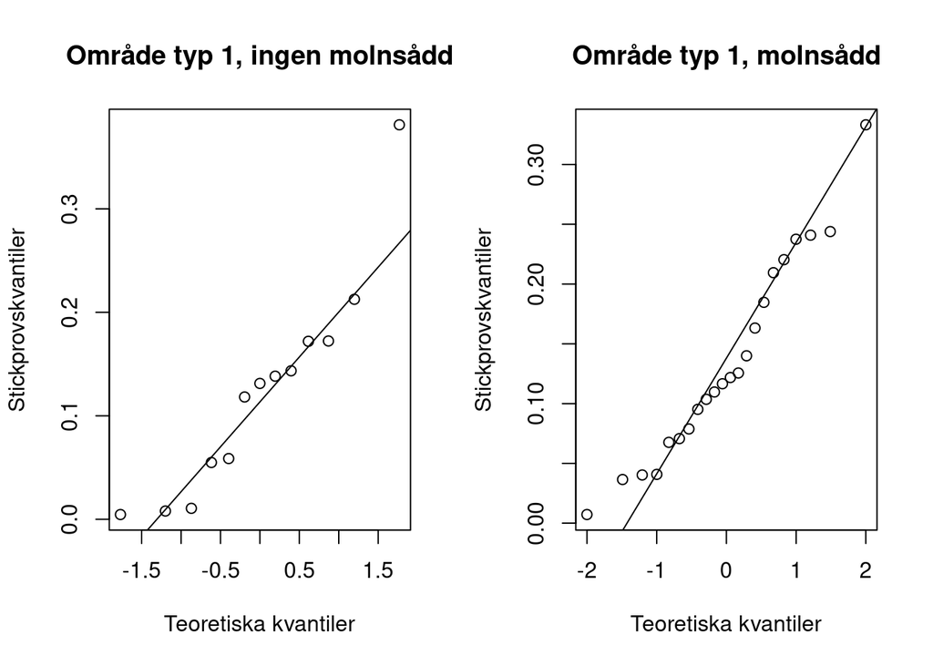

Data från område av typ 1 (stora områden i vindriktningen) presenterat i två normalfördelningsplottar. Ingen molnsådd i figuren till vänster, molnsådd i figuren till höger.

```r
old_par <- par(mfrow = c(1,2))

qqnorm(nonseed_typ1,
       main = "Område typ 1, ingen molnsådd",
       xlab = "Teoretiska kvantiler",
       ylab = "Stickprovskvantiler")
qqline(nonseed_typ1)

qqnorm(seed_typ1,
       main = "Område typ 1, molnsådd",
       xlab = "Teoretiska kvantiler",
       ylab = "Stickprovskvantiler")
qqline(seed_typ1)
```

Det vi ser i figuren ovan är att data från område typ 1 följer en rät linje i normalfördelningsplotten. Mot bakgrund av våra resultat i föregående laboration känner vi oss nöjda med dessa resultat, och tillräckligt säkra för att gå vidare med ett hypotestest för *skillnader i väntevärde mellan två oberoende normalfördelade stickprov*. Se vidare i del 2.2.1.

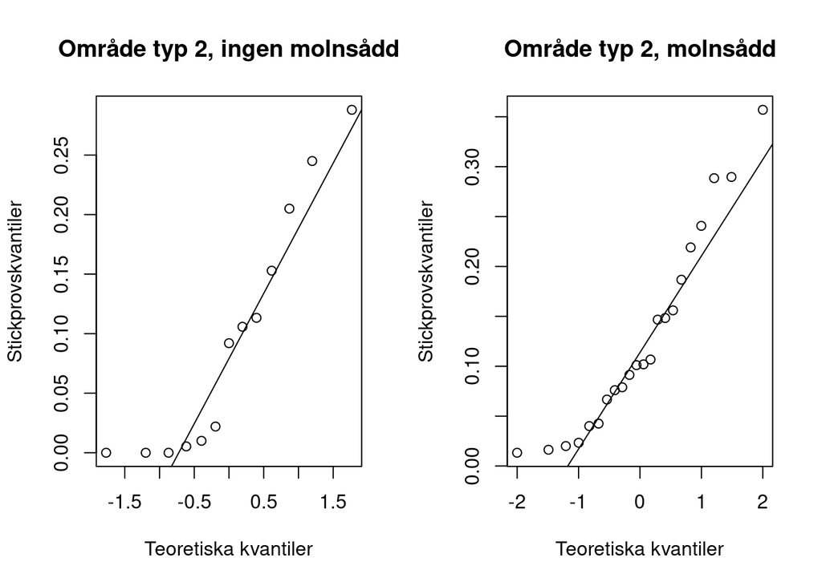

Data från område av typ 2 (mindre områden särskilt känsliga för molnsådd) presenterat i två normalfördelningsplottar. Ingen molnsådd i figuren till vänster, molnsådd i figuren till höger.

```r
old_par <- par(mfrow = c(1,2))

qqnorm(nonseed_typ2,
       main = "Område typ 2, ingen molnsådd",
       xlab = "Teoretiska kvantiler",
       ylab = "Stickprovskvantiler")
qqline(nonseed_typ2)

qqnorm(seed_typ2,
       main = "Område typ 2, molnsådd",
       xlab = "Teoretiska kvantiler",
       ylab = "Stickprovskvantiler")
qqline(seed_typ2)
```

För data från område av typ 2 anar vi en S-formad kurva, vilket får oss att vilja undersöka data i histogram, för att få en bättre uppfattning om fördelnigen och därmed kunna fatta beslut om hypotestest.

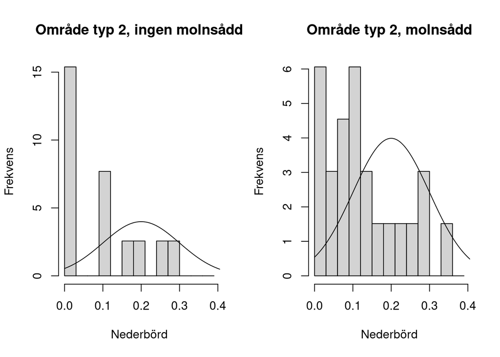

Data från område av typ 2 (mindre områden särskilt känsliga för molnsådd) presenterat i två histogram. Ingen molnsådd i figuren till vänster, molnsådd i figuren till höger.

```r
old_par <- par(mfrow = c(1,2))

hist(nonseed_typ2, breaks = seq(from=0, to=0.4, by=0.03),
     main = "Område typ 2, ingen molnsådd",
     xlab = "Nederbörd",
     ylab = "Frekvens",
     prob = TRUE)
x <-  seq(from = 0, to = 0.5, length.out = 100)
lines(x, dnorm(x,0.2,0.1))

hist(seed_typ2, breaks = seq(from=0, to=0.4, by=0.03),
     main = "Område typ 2, molnsådd",
     xlab = "Nederbörd",
     ylab = "Frekvens",
     prob = TRUE)
x <-  seq(from = 0, to = 0.5, length.out = 100)
lines(x, dnorm(x,0.2,0.1))
```

Mycket riktigt ser vi i figuren ovan en stor avvikelse mellan den teoretiska normalfördelningen (linjen) och vår data (staplarna). Vi känner oss inte trygga med att göra antagande om att data är normalfördelade, och kommer för område 2 därför att utföra ett icke-parametriskt hypotestest, vilket kan utföras utan antagande om fördelnigen.

### 2.2.1 Test för område typ 1

Vår nollhypotes är att det inte föreligger någon skillnad i väntevärde mellan stickproven, alltså $H_0 : \mu_{seed}-\mu_{nonseed}=0$. Vi formulerar en tvåsidig mothypotes, $H_1 : \mu_{seed} - \mu_{nonseed} \neq 0$. Vi utför ett t-test med hjälp av R:s inbyggda funktion:

```r
t.test(nonseed_typ1, seed_typ1, alternative = "two.sided", mu = 0, conf.level = 0.95)
```

```
##
##  Welch Two Sample t-test
##
## data:  nonseed_typ1 and seed_typ1
## t = -0.36159, df = 21.309, p-value = 0.7212
## alternative hypothesis: true difference in means is not equal to 0
## 95 percent confidence interval:
##  -0.08264564  0.05814424
## sample estimates:
## mean of x mean of y
## 0.1235538 0.1358045
```

### 2.2.2 Test för område typ 2

Vår nollhypotes är att det inte finns någon skillnad i väntevärde mellan dagar med molnsådd och dagar utan, $H_0 : \mu_{seed} - \mu_{nonseed} = 0$, och vår mothypotes formuleras tvåsidigt som att det *finns* en skillnad i väntevärde, $H_1 : \mu_{seed} - \mu_{nonseed} \neq 0$.

```r
wilcox.test(nonseed_typ2, seed_typ2,
            alternative = c("two.sided"),
            mu = 0,
            conf.int = TRUE,
            conf.level = 0.95)
```

```
##
##  Wilcoxon rank sum test with continuity correction
##
## data:  nonseed_typ2 and seed_typ2
## W = 108, p-value = 0.2387
## alternative hypothesis: true location shift is not equal to 0
## 95 percent confidence interval:
##  -0.09663490  0.03735689
## sample estimates:
## difference in location
##            -0.03420231
```

*Kommentar:* Vi får en varning av R, vilken beror på att vi har flera identiska värden. Detta gör att vi får en approximation. För skojs skull gör vi en körning med samma test som för stickproven från område av typ 1, det vill säga, vi tänker oss att stickproven ändå är *tillräckligt* normalfördelade.

```r
t.test(nonseed_typ2, seed_typ2, alternative = "two.sided", mu = 0, conf.level = 0.95)
```

```
##
##  Welch Two Sample t-test
##
## data:  nonseed_typ2 and seed_typ2
## t = -0.92228, df = 24.825, p-value = 0.3653
## alternative hypothesis: true difference in means is not equal to 0
## 95 percent confidence interval:
##  -0.10485474  0.04000719
## sample estimates:
##  mean of x  mean of y
## 0.09533077 0.12775455
```

## Diskussion och slutsats

[^1]: Mening kopierad ur laborationsbeskrivningen.